# Assignment 1

- Show All Code
- Hide All Code
- View Source

Published

December 29, 2023

## 1 Introduction

In this report, the followings question will be answered to a survey sent out to all ###. All the questions asked can be found ###. Many of these questions consisted of questions asked by the students. Furthermore, all answered were anonymous and students were able to pick and choose between answering the questions.

```r
suppressWarnings({
  suppressMessages({
  library(tidyverse)
  library(dplyr)

  #install.packages("remotes")
  remotes::install_github("ropenscilabs/gendercoder")
})})
```

### 1.1 Data Wrangling

Using the programming language R it will assist with answering all the questions in the report.. The library tidyverse (H. Wickham, et el.) and gendercode (J. Beaudry, et el.) also helped with cleaning the data. Furthermore, data visualization was performed using the library ggplot2 (H. Wickham).

From our raw data, each row represents a question asked in the survey. However the questions in the survey are very long and too detailed which makes it hard to understand what each row is. Therefore the row names are summarized into keywords (G. Tarr). The variables that will be used in the report will be cleaned individually in each of the subsections. Many of the data cleaning methods were either used directly or adapted from Professor Tarr (G. Tarr). To keep it concise, the rest of the data ignored and remain uncleaned.

```r
x = readr::read_csv("data/DATA2x02 survey (2023) (Responses) - Form responses 1.csv", show_col_types = FALSE)

old_names = colnames(x)


new_names = c("timestamp","n_units","task_approach","age",
              "life","fass_unit","fass_major","novel",
              "library","private_health","sugar_days","rent",
              "post_code","haircut_days","laptop_brand",
              "urinal_position","stall_position","n_weetbix","food_budget",
              "pineapple","living_arrangements","height","uni_travel_method",
              "feel_anxious","study_hrs","work","social_media",
              "gender","sleep_time","diet","random_number",
              "steak_preference","dominant_hand","normal_advanced","exercise_hrs",
              "employment_hrs","on_time","used_r_before","team_role",
              "social_media_hrs","uni_year","sport","wam","shoe_size")
# overwrite the old names with the new names:
colnames(x) = new_names
# combine old and new into a data frame:
name_combo = bind_cols(New = new_names, Old = old_names)
# name_combo |> gt::gt()
```

### 1.2 General Discussion

1. Is this a random sample of ### students?

This data is not a random sample of ### students since the data is subjected to selection bias. This is because based on the students convenience and availability, they might of not had the opportunity to participate. This results to the sample not being random and relies on voluntary participation. Furthermore it shall be noted that the survey was mentioned 3 times, in the lectures, in the lab, and on ed. This may have lead to a hidden confounder. Students who are up to date with their work will attend the lectures and lab, and therefore answer the survey before the deadline. Whilst those students who are not up to date with their work will not answer the survey in time.

2. What are the potential biases? Which variables are most likely to be subjected to this bias?

Selection Bias. This is the main bias in this study as mentioned above. This would of affected the entire dataset resulting in it not being able to represent the population. However the data may still provide valuable insights for the following questions asked in the report.

Data entry Bias. This happens when someone puts an unfeasible input in the survey. In the variable age, someone put has put down the ages of 1, 184, 400. We know this is untrue since it is outside the realistic age of a person studying at university. This can also be seen in other variables where the input allows the user to type in arbitrary answers. Some other variables such as sleep_time have answers that include emojis. In height there are also ambiguous answers such as “really quite tall”.

Cultural and Language Bias. Shoe size and age are commonly linked to this type of bias. Since there is a large body of students coming from diverse cultural backgrounds, shoe_size may mean different things for people. There are multiple different ways of representing a shoe size such as the US, UK, EU format and shoe sizes being represented in CM (centimeters) and IN (inches). Furthermore, shoe size is also different for men and women. Another one is how different cultures count ages.

In addition, Koreans use a different system to count the age of a person compared to the western system. (S. Price) This therefore may have conflicts in the answer in relation to the person “true age”.

3. Which questions needed improvement to generate useful data (e.g. in terms of the way the question was phrased or response validation)?

To help with dealing with invalid inputs, all of the options should be where students are only allowed to select one options out of a list of option. This could be done with creating a slider for continuous variables or writing down all of the possible answers for discrete variables. However a limitation is that variables such as favorite social media app and gender may have too many different answers for this method to be possible.

Another way reduce the ambiguity of the question is to ask put in a measurement in the questions. For example, let us use the variable heights. Instead of asking “How tall are you”, it could be rephrased to how tall are you (cm). This could also be applied for other questions that may require a measurement such as time measured in hours, or shoe size in men/women US size.

## 2 Results

### 2.1 Is there a significant association between dietary preference(such as vegans, vegetarian, omnivorous, pescatarian or other) and the toilet stall position amongst ### students?

**Rational:** Although initially dietary preference and toilet stall position may seem unrelated. However it may be interesting figure out if a dietary preference has a relation to toilet stall positions. Potential applications may be used in targeted advertising in toilet stall where a company wants to promote their product to certain consumers with dietary preferences.

Note: explanation of cleaning the data is in the appendix.

```r
stall_position_and_diet <- data.frame(x$stall_position, x$diet)

stall_position_and_diet <- stall_position_and_diet |>
  dplyr::mutate(

    x.diet = tolower(x.diet),

    x.diet = ifelse(x.diet %in% c("all", "healthy", "normal"), "omnivorous", x.diet),

    x.diet = ifelse(x.diet %in% c("no red meat"), "pescatarian", x.diet)
  )


missing_rows_1 <- is.na(stall_position_and_diet$x.stall_position) | is.na(stall_position_and_diet$x.diet)
# uncomment this to double check if comfortable with removing these values
#print(stall_position_and_diet[missing_rows_1, ])


cleaned_stall_position_and_diet <- stall_position_and_diet[!missing_rows_1, ]
```

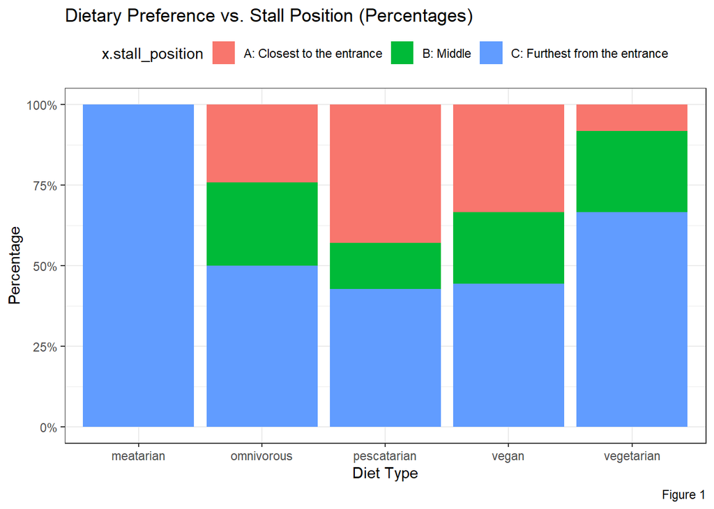

```r
p1 <- ggplot(cleaned_stall_position_and_diet, aes(x = x.diet, fill = x.stall_position)) +
  geom_bar(position = "fill") +
  labs(
    title = "Dietary Preference vs. Stall Position (Percentages)", caption = "Figure 1", x = "Diet Type", y = "Percentage", color = "Stall Position") +
  scale_y_continuous(labels = scales::percent_format(scale = 100)) +
  theme_bw() +
  theme(legend.position = "top")
p1
```

However to test this statistically, we are using a chi-squared test for independence as we want to check if there is an association between two independent discrete variables. However the assumption where all the cells have an expected counts of greater than 5 ($e_{ij} >= 5$) must be met. In our case this assumption was not met and required a simulation approach to answer the question. Since we have used a simulation, we want to set the seed so it allows reproducibility in our data.

```r
contingency_table <- table(cleaned_stall_position_and_diet$x.diet, cleaned_stall_position_and_diet$x.stall_position)

# checking for assumption where expected cell counts are greater than 5
# result <- chisq.test(contingency_table)
# expected_freqency <- result$expected
# print(expected_freqency)

set.seed(1)
result <- chisq.test(contingency_table, simulate.p.value = TRUE)
```

1. **Hypothesis:** $H_0$: there is no association between between dietary preference and toilet stall preferences. $H_1$: there is an association between dietary preference and toilet stall preferences.
2. **Assumptions:** We also assume there is independence between dietary preference and toilet stall positions.
3. **Test statistics:** $\sum_{i=1}^{3}\sum_{j=1}^{5} ({y_{ij} - e_{ij}})^2 / {e_{ij}}$ ~ $\chi_{8}^{2}$
4. **Observed Test statistics:** 4.7132
5. **P-value:** 0.8481
6. **Decision:** Since the p-value of 0.8481 is greater than the significance level of 0.05, we have sufficient evidence to retain the null hypothesis. In other words, there is not enough statistical significance to prove there is an association between dietary preference and the toilet stalls chosen by Data2x02 students.

### 2.2 Is the numbers selected by Data2x02 students really random?

**Rational:** Analyzing if Data2x02 students picked random numbers from 0 - 9 is interesting as we want to investigate if this process of picking numbers is truly random. Since the numbers were ordered from 0 - 9 down the survey, it would be more interesting to see if the numbers were in a randomly generated order, would there be any difference in the randomness of number picking.

Note: explanation of cleaning the data is in the appendix.

```r
cleaned_random_number = na.omit(x$random_number)
```

In figure 2 we would expect that the distribution of each number is around the same. However this is not the case as there is a greater frequency or preference for the numbers 6 and 7 over the others.

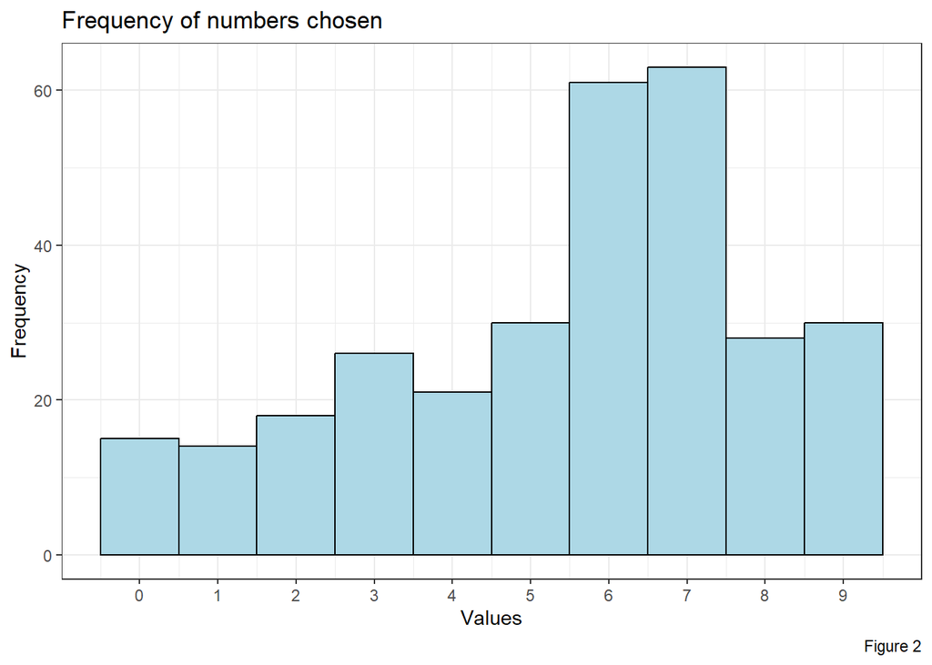

```r
p2 <- ggplot() +
  aes(x = cleaned_random_number) +
  geom_histogram(binwidth  = 1, fill = "lightblue", color = "black") +
  labs(title = "Frequency of numbers chosen", caption= "Figure 2", x = "Values", y = "Frequency") +
  theme_bw() +
  scale_x_continuous(breaks = seq(0, 9, 1))

p2
```

However to test this statistically, a chi-squared goodness of fit test would need to be performed. To perform this test, the assumption where all the cells have an expected counts of greater than 5 ($e_{ij} >= 5$) have been met.

```r
prob <- rep(0.1, times = 10)
e_i = prob * length(cleaned_random_number)

random_number_freq = table(cleaned_random_number)
result2 <- chisq.test(random_number_freq, p = prob)
```

1. **Hypothesis:** $H_0$: The numbers picked by Data2x02 students follow a uniform distribution. $H_1$: The numbers picked by Data2x02 students does not follow a uniform distribution.
2. **Assumptions:** We assume that there is independence in the numbers picked by Data2x02 students. We also assume that the expected cell counts are larger than 5 $e_{ij} >= 5$.
3. **Test statistics:** $\sum_{i=1}^{306}({y_{i} - e_{i}})^2 / {e_{i}}$ . Under $H_0$, T ~ $\chi_{9}^{2}$
4. **Observed Test statistics:** 90.601
5. **P-value:** $1.233^{-15}$
6. **Decision:** Since the p-value of 1.223e-15 is much smaller than the significance level of 0.05, we have sufficient evidence to reject the null hypothesis. In other words, the numbers picked by Data2x02 students are not random.

However, it could be suggested that there were not enough students picking random numbers for the law of large numbers to occur. This is because in the short term, the observation were inconsistent with the numbers picked being not uniformly distributed.

### 2.3 Is there a significant difference in the weekly study hours between male and female DATA2X02 students.

**Rational:** Gender equality is often a common issue in the modern day. Therefore it is interesting to see if there is any discrepancy in the amount of work put into their study between female and male students in the class for Data2x02.

Note: explanation of cleaning the data is in the appendix.

```r
x = x |> mutate(
  gender_clean = gendercoder::recode_gender(gender)
)

# x |> janitor::tabyl(
#   gender, gender_clean
# ) |> gt::gt() |>
#   gt::tab_spanner(label = "Recoded outcomes", columns = 2:5) |>
#   gt::cols_label(gender = "Original outcomes")
#
#
# x |>
#   ggplot() +
#   aes(x = x$study_hrs) +
#   geom_histogram(binwidth = 5)+
#   labs(x = "Count", y = "Height (cm)") +
#   theme_bw()
#
# x |>
#   filter(x$study_hrs > 100) |>
#   View()

gender_and_study_hrs <- data.frame(x$gender_clean, x$study_hrs)

gender_and_study_hrs <- gender_and_study_hrs |>
  dplyr::mutate(

    x.gender_clean = ifelse(x.gender_clean %in% c("non-binary"), NA, x.gender_clean),

    x.study_hrs = if_else(x.study_hrs < 100, x.study_hrs, NA)
  )

missing_rows_3 <- is.na(gender_and_study_hrs$x.gender_clean) | is.na(gender_and_study_hrs$x.study_hrs)
# print(gender_and_study_hrs[missing_rows_3, ])

cleaned_gender_and_study_hrs <- gender_and_study_hrs[!missing_rows_3, ]
```

In figure 3, the distribution between male and women study hours look about the same with the exception of outliers in the male section.

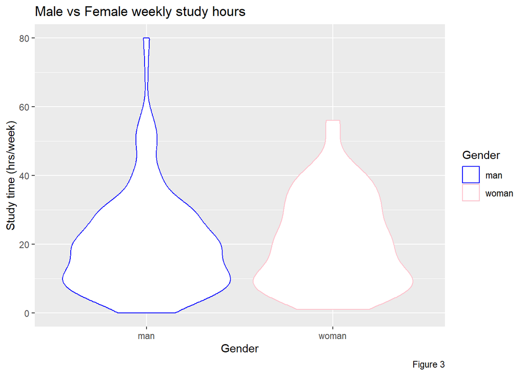

```r
p3 <- ggplot(cleaned_gender_and_study_hrs, aes(x = x.gender_clean, y = x.study_hrs, colour = x.gender_clean)) +
  geom_violin() +
  scale_color_manual(values = c("blue", "pink")) +
  labs(title = "Male vs Female weekly study hours", caption = "Figure 3", y = "Study time (hrs/week)", x = "Gender", color = "Gender")

p3
```

However to test this statement statistically, either a t-test or Wilcoxon ranked-sum test will be performed. However to perform a t-test the normality assumption must be met. The box plot in figure 4 shows that there is more symmetry in the female study hours compared to male. But looking at normal quantile plot in figure 5, it shows that both female and male study hours is clearly not normally distributed. Therefore a Wilcoxon ranked-sum test must be performed as the normality assumption is violated.

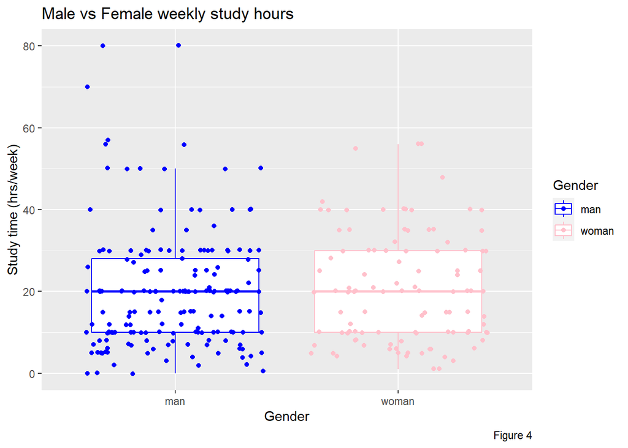

```r
suppressMessages({
  p4 <- ggplot(cleaned_gender_and_study_hrs, aes(x = x.gender_clean, y = x.study_hrs, colour = x.gender_clean)) +
    geom_boxplot(outlier.shape = NA) + #remove outliers so not confused with jitter
    geom_jitter() +
    scale_color_manual(values = c("blue", "pink")) +
    labs(title = "Male vs Female weekly study hours", caption = "Figure 4", y = "Study time (hrs/week)", x = "Gender", color = "Gender")

  p4
})
```

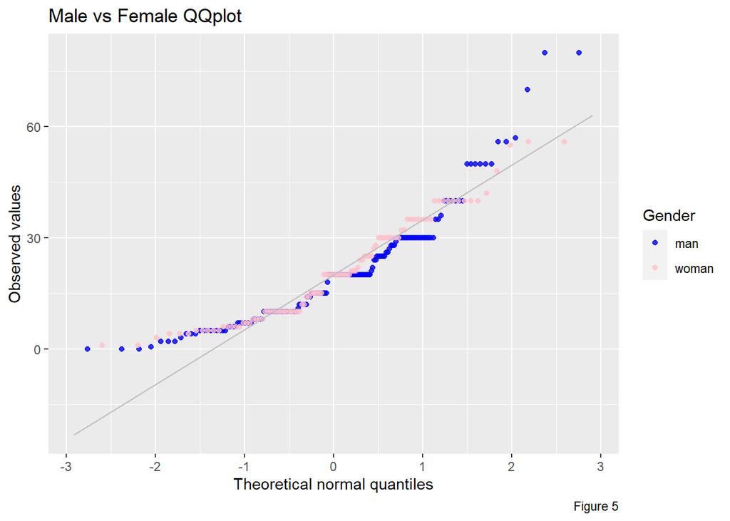

```r
 p5 <- ggplot(cleaned_gender_and_study_hrs, aes(sample = x.study_hrs, colour = x.gender_clean)) +
    geom_qq(alpha = 0.8) +
    geom_qq_line(color = "grey") +
    scale_color_manual(values = c("blue", "pink")) +
    labs(title = "Male vs Female QQplot", caption = "Figure 5", x = "Theoretical normal quantiles", y = "Observed values", color = "Gender")

p5
```

```r
man_study_hrs <- subset(cleaned_gender_and_study_hrs, x.gender_clean == "man")
woman_study_hrs <- subset(cleaned_gender_and_study_hrs, x.gender_clean == "woman")

result3 <- wilcox.test(man_study_hrs$x.study_hrs, woman_study_hrs$x.study_hrs)
```

Let $\mu_m$ and $\mu_f$ be the average weekly hours of study from a male and female Data2x02 student respectively.

Let $R_i$ be the ranks.

Let $n_m$ and $n_f$ be the number of male and female students respectively.

**Decision:** Since the p-value of 0.4671 is greater than the significance level of 0.05, we have sufficient evidence to retain the null hypothesis. This means that there is no significance difference between the weekly study hours of a male and female Data2x02 student.

## 3 Conclusion

In conclusion, although there is selection bias in the data set, the data still provided useful insight into the questions in the report.

First of all, from the data there is no association between dietary preference and preference of toilet stall in the class of Data2x02 students.

The numbers picked by Data2x02 students are not random.

Finally there is no significance difference between the weekly study hours of a male and female Data2x02 student.

## 4 References

DATA2x02 students. (2023). DATA2x02 class survey. Retrieved August 22, 2023, from https://docs.google.com/spreadsheets/d/e/2PACX-1vR9Ve_Zi-dM5K96ku2tnmaMrpX3Gk3y9KHcYsNIkzyyna8tRWOxBt_iDsZI_UzXFHLidPU6vY9bml4n/pub?output=csv

Beaudry, J., Kothe, E., Singleton Thorn, F., McGuire, R., Tierney, N., & Ling, M. (2023). *Gendercoder: Recodes sex/gender descriptions into a standard set*. https://github.com/ropensci/gendercoder

Wickham H, Averick M, Bryan J, Chang W, McGowan LD, François R, Grolemund G, Hayes A, Henry L, Hester J, Kuhn M, Pedersen TL, Miller E, Bache SM, Müller K, Ooms J, Robinson D, Seidel DP, Spinu V, Takahashi K, Vaughan D, Wilke C, Woo K, Yutani H (2019). “Welcome to the tidyverse.” _Journal of Open Source Software_, *4*(43), 1686. doi:10.21105/joss.01686 https://doi.org/10.21105/joss.01686.

H. Wickham. ggplot2: Elegant Graphics for Data Analysis. Springer-Verlag New York, 2016 https://ggplot2.tidyverse.org/.

G. Tarr. Data importing and cleaning guide, 2023,

Price, S. (2023, July 27). Korean Age - calculator and explanation of the system. 90 Day Korean. https://www.90daykorean.com/korean-age-all-about-age-in-korea/

## 5 Appendix

### 5.1 Cleaning for question 1

With the variable toilet stall position, it entry only consisted of 1 choice out of 3 answers. This meant that all the answered are already in a very clean state.

Furthermore with the variable diet, there is language bias in the data as there were a few entries that may have been confused the students with the scientific jargon. This is because they have put in alternative answer such as “all, healthy, meatarian, no red meat and normal” from the original 4 of vegans, vegetarian, omnivorous, pescatarian. Therefore we can assume all, healthy, and normal to be omnivorous and no red meat to be pescatarian. Furthermore we will put meatarian on its own category.

Since all the answers to each questions were voluntary, some students have chosen to answer one question over the other which resulted in a combination of non existent (*NA*) data entries. Furthermore we have also added some of our own due to unreasonable entries in the data. Therefore before we remove them we must be comfortable rejecting all these options.

### 5.2 Cleaning for question 2

With the variable random_number, since the inputs are already given to you from the order 0 - 9 there is no room for wrong inputs. Therefore the only bit of cleaning needed to do was to remove the NULL answers from people who didn’t answer the question.

### 5.3 Cleaning for question 3

With the variable gender, students had free-form to put any answers they want. Using gendercode (J. Beaudry), it sorts all of the inputs into 4 categories (man, woman, non-binary and NA).

Finally we want to check if we are comfortable with removing all the NA values.